# Installing R Studio Server on Amazon Web Services EC2 Instance

Katie Heineman

1/27/2020

# Why Use Cloud Computing for R

Big datasets often require more computational power (CPU) and memory (RAM) than your local computer has to offer. Image analysis in particular might require specialized hardware (GPU) that are not present in all traditional personal computers. Also, regardless of the specific hardware, it can be nice to decouple slow running analyses from your local machine so that closing your computer doesn’t mean stopping an analysis.

# References for this Tutorial

- I am borrowing very heavily from the AWS page on the subject: https://aws.amazon.com/blogs/big-data/running-r-on-aws/

# What We Will Do Today

- Sign up for an AWS Account (Free Tier) **REQUIRES CREDIT CARD**
- Create an EC2 compute instance
- Install R, RStudio, and Shiny on a Linux OS
- Run a “chron job” [MAYBE IF TIME]

# Creating AWS Account

- Go to https://aws.amazon.com/free/?all-free-tier.sort-by=item.additionalFields.SortRank&all-free-tier.sort-order=asc
- Create New Amazon Account
- You will have to enter credit card
- Select the Basic Plan - “Free Tier” **Let’s Regroup after everyone has logged into their console**

[figure not shown]

# Launching an AWS EC2 Instance

## What is an Image?

- An “Image” is the operating system or software that interfaces with the “Instance” or machine that does the computating
- The term “image” is used on many cloud computing platforms, but AMI references explicitly to an **Amazon Machine Image**
- Commonly used imaged include those for linux operating systems (Ubuntu, CentOS) and also Windows images that can allow you to remote desktop in to an image ## Selecting an Image (AMI) for your Instance
- Click “Launch Virtual Machine” on AWS console page
- Type “ubuntu” in the search bar and select the first instance

[figure not shown]

## Selecting Your Instance

-An instance is the “machine” behind the computation. -To select the correct instance, you want to consider primarily how many CPU (cores) and memory (RAM) you need for your analysis. This often involves agreat deal of trial and error -Form the AWS tutorial on this R installation they recommend the following for R usage: “The M4 instance family is often a good choice for R workloads. If you use R packages such as foreach, parallel, or snow to parallelize, we recommend using the bigger M4 instance types. They provide a good mix of CPU power and memory.” -Only micro instances are eligible for the free tier, so our choice is easy

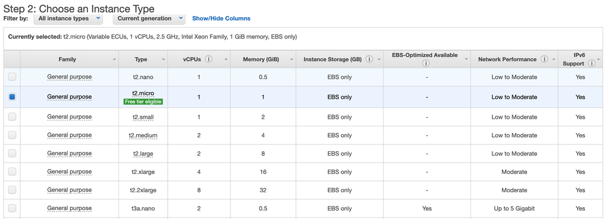

# Configure Security Groups/Open Ports

- If you do not open specific ports in your instance firewall, Rstudio Server and Shiny Server will not work
- Specify 8787 as Rstudio Server
- Specify 3838 as Shiny Server
- Specify Source as Anywhere - ideally… you would only want to do your home IP, work IP, or VPN, but this is fine for now

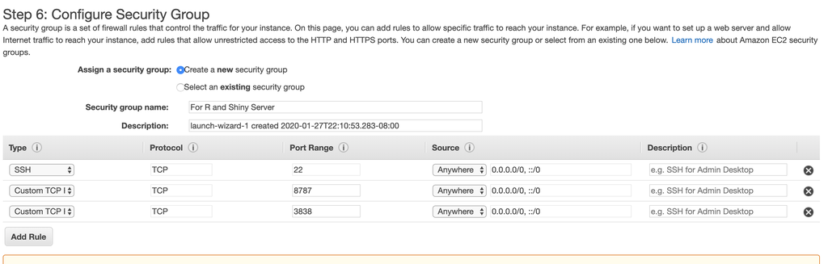

# READY… SET…. LAUNCH YOUR INSTANCE!

- Check the box next to your instance and click “connect”

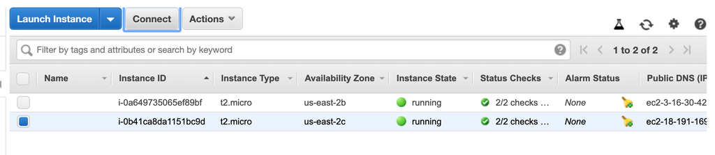

- You should be asked to save your ssh key, which is a file with the extension .PEM. Story this in a directory you can easily access.

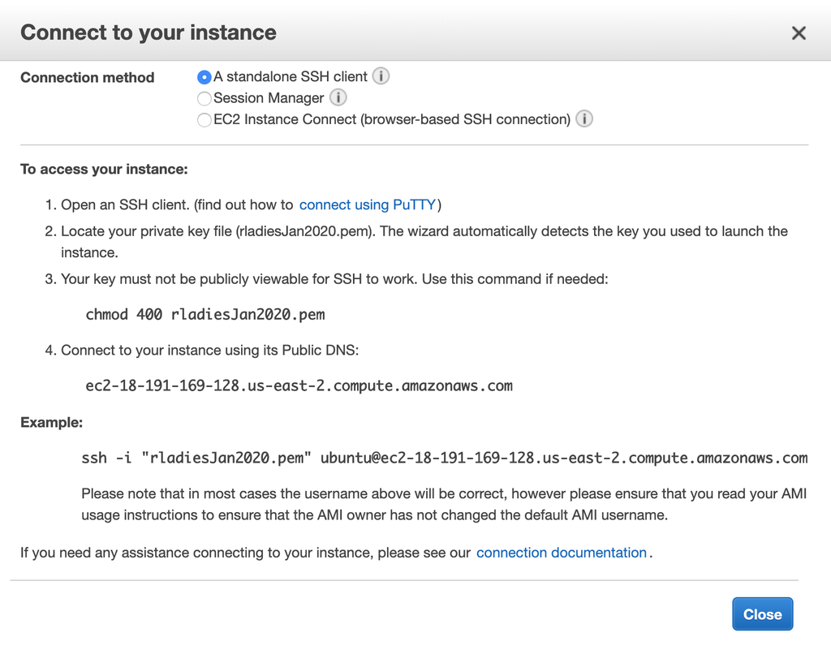

# Connecting to an Instance Through Your Terminal (Linux/Mac)

- Step 1: Open your terminal on your computer
- Navigate to the directory where you stored your ssh key (.pem) using the linux command “cd” & “ls”
- Run the code below in your terminal to “SSH in” to your machine

```bash
ssh -i "rladiesJan2020.pem" ubuntu@ec2-18-191-169-128.us-east-2.compute.amazonaws.com
```

- When you have successfully connected to your ubuntu instance, you should see the “user” name of the terminal change from your local computer (katieheineman) to “ubuntu@ip-XXX-XX-XXX’

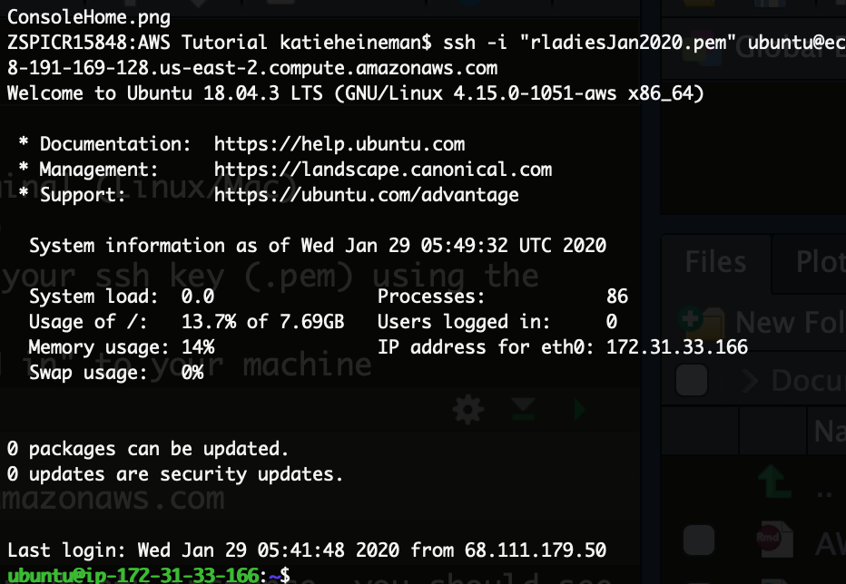

# Install software on your instance (Including Rstudio)

```bash
sudo su

# Install some basic tools - many of this critical for R studio server
apt-get update && apt-get install -y \
    sudo \
    gdebi-core \
    pandoc \
    pandoc-citeproc \
    libcurl4-gnutls-dev \
    libcairo2-dev \
    libxt-dev \
    net-tools

# Create Environmental variable for later installs
PYTHONIOENCODING=UTF-8

# Add install shell script
apt-get update && apt-get install -y --no-install-recommends apt-utils
apt-get install wget

# Default install
apt-get install -y \
    less \
    man \
    python \
    python-pip \
    python-virtualenv \
    nano \
    lzop \
    openssl \
    sudo \
    gdebi-core \
    pandoc \
    pandoc-citeproc \
    libcurl4-gnutls-dev \
    nano \
    curl \
    p7zip-full \
    pigz \
    openssl \
    libssl-dev

# Install more dependencies
apt-get install -y libxml2-dev
apt-get install -y libcurl4-openssl-dev
apt-get install -y libssl-dev
apt-get install -y libcairo-dev
apt-get install -y gdebi-core

# Install AWS CLI
pip install awscli

# Install R - This will install the lastest version
apt install -y apt-transport-https software-properties-common
apt-key adv --keyserver keyserver.ubuntu.com --recv-keys E298A3A825C0D65DFD57CBB651716619E084DAB9
add-apt-repository 'deb https://cloud.r-project.org/bin/linux/ubuntu bionic-cran35/'
apt update
apt install -y r-base
apt install -y r-base-dev
apt-get install -y r-cran-littler

# Install packages on Linux more quickly!
add-apt-repository -y ppa:marutter/c2d4u3.5
apt-get update
apt install -y r-cran-rgl r-cran-rjags r-cran-snow r-cran-ggplot2 r-cran-igraph r-cran-lme4 r-cran-rjava r-cran-devtools r-cran-roxygen2 r-cran-rjava r-cran-xlsx

# Install R Shiny
apt install -y r-cran-shiny

# Install rstudio-server (MAKE SURE TO DO THIS IN THE ROOT FOLDER)
cd /root
wget https://download2.rstudio.org/server/trusty/amd64/rstudio-server-1.2.5001-amd64.deb
gdebi -n rstudio-server-1.2.5001-amd64.deb

# Install shiny-server
wget https://download3.rstudio.org/ubuntu-14.04/x86_64/shiny-server-1.5.12.933-amd64.deb
gdebi -n shiny-server-1.5.12.933-amd64.deb
```

# Visit Your Very Own Rstudio Server!

-Once software is installed… try to visit your Rstudio Server in your browser by enter your instance’s external IP address followed by “:8787” (which is the port we opened. See below where you can find your instance’s IP address in the AWS console

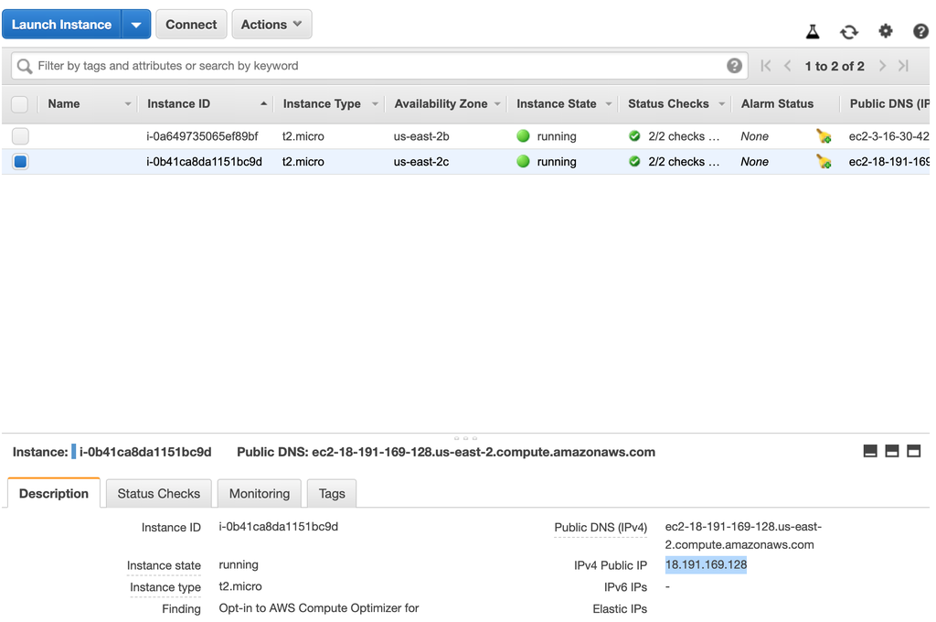

-After pasting your IP + port into the browser, You should now see the authenication page for Rstudio server

[figure not shown]

# Create User for Rstudio Server

```bash
useradd -m katieRlady
passwd katieRlady
```

# Trouble Shooting

```bash
# Uninstall Rstudio Server
apt-get remove purge rstudio-server
apt-get remove purge shiny-server
```